# Detecting Common Lifting Errors from Tracker Data

Matthew Halbasch

March 31, 2019

## Overview

Recent years have seen an explosion in the usage of fitness tracking devices to quantify the amount and type of exercise being done. However, not much attention is given to quantifying how *well* an exercise is being performed. In this report, we use data from sensors on participants’ arm, hand, belt and dumbell to classify whether a barbell exercise was performed correctly or falling into one of several common mistakes. We build a machine learning model to make this classification, and achieve an accuracy of 96% on a held-out testing set. These results rely on several sensors providing data simultaneously, complicating real-time detection, but remain promising for mistake detection in the future.

## Cleaning the Data

The data for this project comes from the Weight Lifting Exercises Dataset avaialbe [here](http://web.archive.org/web/20161224072740/http:/groupware.les.inf.puc-rio.br/har). It consists of measurements from four sensors located on participants’ belt, arm, hand, and barbell, measured during performance of a biceps curl. The experiment recorded six participants, each of whom performed the exercise in five distinct ways:

- Correctly (Class A)
- Throwing elbows forward (Class B)
- Lifting the Dumbell only halfway (Class C)
- Lowering the Dumbell only halfway (Class D)
- Throwing hips forward (Class E)

Each sensor provides measurements for acceleration, gyroscope and magnetometer data along three axes. The [data](https://d396qusza40orc.cloudfront.net/predmachlearn/pml-training.csv) used for this report includes these measurements as well as several calculated aggegrate features. These calculated features correspond to windows of measurements, aggregated by mean, standard deviation, maximum, etc. We have chosen to disregard these additional features in our analysis for later prediction purposes, so we may extrapolate from a single measurement on unseen data.

Accordingly, we selected only the complete measurements at each time step as features, disregarding the window and time stamps. We were left with 52 features for prediction, with 19,622 complete observations. We split these observations into three distinct groups: a training set of 11,776 observations as well as a validation and quiz set, each containing 3,923 observations.

## Building the Model

The prediction model was built in three stages:

- First, we split the training set with 10-fold cross-validation, and built a random forest classifier for each of these ten folds.
- Second, we used the validation set to stack these 10 classifiers into a single classifier, again using a random forest model. This stacked model is trained on the validation set according to the original model’s predictions, and is our final classifier.
- We finally evaluated the performance of this stacked model on the quiz set to obtain a good estimate of the out-of-sample error of the model.

This section examines each of these steps in detail.

### Training Set Classifiers

We first broke the training set into ten distinct folds, each approximately containing 1,178 observations. These folds were chosen randomly with the constraint that each of the five prediction classes are well-represented in each fold.

We then training a random forest classifier on each fold, using the other nine folds as a validation set to decide the number of trees to use in each forest. We prioritized accuracy when deciding the number of trees to choose for the final model in each fold. This produced 10 different classifiers, each of which used between 75 and 200 trees. Their structure and validation performance are featured in the table below.

| model | Number of Trees | Validation Accuracy |
| --- | --- | --- |
| 1 | 75.00 | 91.5% |
| 2 | 100.00 | 90.8% |
| 3 | 200.00 | 92.7% |
| 4 | 150.00 | 92.5% |
| 5 | 150.00 | 92.8% |
| 6 | 200.00 | 91% |
| 7 | 150.00 | 92.5% |
| 8 | 150.00 | 93.2% |
| 9 | 150.00 | 92.2% |
| 10 | 150.00 | 91.6% |

We see that each of these models performs with over 90% accuracy on their validation sets, but this is not a good measure of out-of-sample error, as we have chosen the number of trees to maximize the accuracy in each case. We next look at how we measured and improved the out-of-sample error of these predictors.

### Stacking the Classifiers

We next used the validation set described beforehand to estimate the out-of-sample error of these 10 predictors. To improve on this error, we ‘stacked’ the classifiers by using their predictions on the validation set as features for a new random forest model to be trained on the validation set. That is, our stacked classifier takes the predictions from our ten models as input, and outputs its own classification, trained according to the actual labels of the validation set.

We chose to use 100 trees for this stacked random forest, and it achieved a 99% accuracy on the validation set (its training set, so this does not estimate the out-of-sample error).

### Testing the Stacked Model

Finally, to get a true estimate of the out-of-sample error of the final model, we evaluated its performance on the quiz set. To illustrate its performance relative to the 10 individual classifiers we have briefly summarised their accuracy on this set in the table below.

| model | Quiz Accuracy |
| --- | --- |
| 1 | 91.2% |
| 2 | 90.7% |
| 3 | 92.5% |
| 4 | 92.2% |
| 5 | 92.6% |
| 6 | 90.9% |
| 7 | 92.7% |
| 8 | 93.4% |
| 9 | 92.4% |
| 10 | 92.1% |
| Stacked | 96.3% |

We see that the stacked classifier achieves a significantly better accuracy than any of the individual classifiers, with 96.3% accuracy on the quiz set. We expect that this will be a good measure of the out-of-sample error for this classifier, as it was trained with no information about the quiz set.

Focusing on this stacked classifier in particular, we have provided the confusion matrix on the quiz set in both table and figure form below.

```
          Reference
Prediction    A    B    C    D    E
         A 1086   19    0    0    0
         B   19  720   23    0    1
         C    5   18  650   25    4
         D    5    0   10  613    9
         E    1    2    1    5  707
```

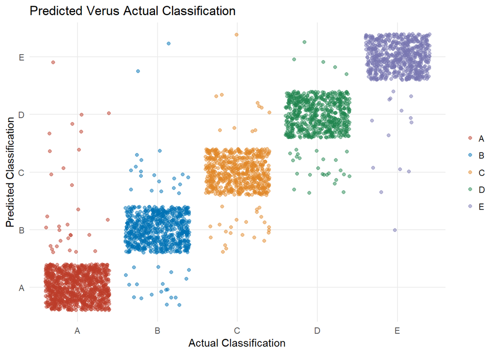

## Conclusion

Using a stacked random forest model, we are able to identify with an estimated 96% accuracy the form of exercise being performed. This was accomplished with only raw data output from four sensors, offering hope that future advancements can turn this type of analysis into real-time feedback. This can help bring the use of technology in fitness from telling us how much we have done to informing *how* we do our exercises.

## Code Appendix

```r
# Silence the code output until the appendix
knitr::opts_chunk$set(echo = FALSE)

# Load the necessary packages
library(tidyverse)
library(caret)
library(xtable)
library(ggsci)

# Read the raw data in directly from their urls
training_url <-"https://d396qusza40orc.cloudfront.net/predmachlearn/pml-training.csv"
testing_url <-"https://d396qusza40orc.cloudfront.net/predmachlearn/pml-testing.csv"

# Need to set the '#DIV/0!' entries to 'NA' for our analysis
train_raw <- read_csv(training_url, na = c("", "NA", "#DIV/0!"))
test_raw <- read_csv(testing_url, na = c("", "NA", "#DIV/0!"))

# Many columns are summary statistics for windows which we will not have
# available for the test set. These columns contain NA values, so we will
# select only non-NA columns.
not_any_na <- function(x) all(!is.na(x))

# Additionally, we remove the labelling information including time and
# user name from the feature space.
train_raw  %>% select_if(not_any_na) %>%
  select(-c(X1, user_name, raw_timestamp_part_1, raw_timestamp_part_2,
            new_window, num_window, cvtd_timestamp)) -> train

# Now we repeat the same actions for the testing dataset, also removing the
# window number, as each observation occurs in a single window slice.
test_raw %>% select_if(not_any_na) %>%
  select(-c(X1, user_name, raw_timestamp_part_1, raw_timestamp_part_2,
            new_window, num_window, cvtd_timestamp)) -> test
# Now we will create the training, "quiz" and validation splits.
# First we split the quiz from the rest of the data.

set.seed(10120) # for reproducibility
part <- createDataPartition(train$classe, p = 0.8)

quiz <- train[-part$Resample1, ]
not_quiz <- train[part$Resample1,]

# Next, within the not_quiz set, we need to make a training and a validation
# set. We are going for a 60/20/20 split, so we need 3/4 of the non-quiz set
# for training.
part2 <- createDataPartition(not_quiz$classe, p = .75)

training <- not_quiz[part2$Resample1, ]
validation <- not_quiz[-part2$Resample1, ]

# We will next focus on just the training set, where we will use k-fold cross
# validation. We use k = 10
folds <- createFolds(training$classe, k = 10)

# For each of these folds, we will train a random forest
model_list <- list(0,0,0,0,0,0,0,0,0,0)
set.seed(53210) # for reproducibility
for(i in 1:length(folds)){
  tr <- training[folds[[i]], ]
  ts <- training[-folds[[i]], ]

  # We will try a few different values for ntree, using the test set to pick
  # the best one in each cross-validation set.
  ntrees <- c(50, 75, 100, 150, 200)
  tree_list <- list(0,0,0,0,0)
  for(j in 1:length(tree_list)){
    n <- ntrees[j]
    model <- train(classe ~ ., data = tr, method = "rf", ntree = n)
    tree_list[[j]] <- model
  }

  # Now we test our models on the ts set, and extract the accuracy
  accs <- sapply(tree_list,
                 function(x) confusionMatrix(factor(predict(x, ts)),
                                             factor(ts$classe))$overall[1])

  # Finally we take the model with the best accuracy
  model_list[[i]] <- tree_list[[which(accs == max(accs))[1]]]
}

# Here we produce a table summarising the 10 models and their accuracy
validation_table <- data.frame(model = 1:10, ntree = rep(0,10), acc = rep(0,10))
for(i in 1:length(model_list)){
  model <- model_list[[i]]
  ts <- training[-folds[[i]], ]
  validation_table[i, 2] <- model$finalModel$ntree
  validation_table[i, 3] <- confusionMatrix(factor(predict(model, ts)),
                                            factor(ts$classe))$overall[1]
}

validation_table %>% rename(`Number of Trees` = ntree) %>%
  mutate(acc = paste0(100*round(acc, 3), "%")) %>%
  rename(`Validation Accuracy` = acc) %>%
  xtable(align = c("c","c","c","c")) %>%
  print(type = "html", include.rownames = F)

# Now we take each of our 10 models selected in cross-validation, and
# use them to predict the validation set.
preds <- sapply(model_list, function(x) predict(x, validation))
pred_df <- cbind(as.data.frame(preds), actual = validation$classe)

# Next we stack these 10 models using a random forest to create a final model
set.seed(8401) # for reproducibility
final_model <- train(actual ~ ., data = pred_df, method = "rf", ntree = 100)

# Finally, we apply this model to the quiz set
quiz_pred_df <- as.data.frame(sapply(model_list, function(x) predict(x, quiz)))
quiz_preds <- predict(final_model, quiz_pred_df)

# We want to compare the accuracies, so we calculate the accuracy for each model
accs <- apply(quiz_pred_df, MARGIN = 2,
              function(x) confusionMatrix(factor(x),
                                          factor(quiz$classe))$overall[1])

final_acc <- confusionMatrix(factor(quiz_preds),
                             factor(quiz$classe))$overall[1]

# Now we organize these into a table
stack_table <- data.frame(model = as.character(1:10), acc = accs,
                          stringsAsFactors = FALSE)
stack_table <- rbind(stack_table, list("Stacked", final_acc))

stack_table %>% mutate(acc = paste0(100*round(acc, 3), "%")) %>%
  rename(`Quiz Accuracy` = acc) %>%
  xtable(align = c("c","c","c")) %>%
  print(type = "html", include.rownames = F)

# First we output the table from the confusion matrix
confusion_matrix <- confusionMatrix(factor(quiz_preds), factor(quiz$classe))
confusion_matrix$table

# Next we create a visualization of the confusion matrix
results <- data.frame(pred = quiz_preds, actual = quiz$classe)

ggplot(results, aes(x = actual, y = pred, color = actual)) +
  geom_jitter(alpha = 0.5) +
  theme_minimal() +
  labs(title = "Predicted Verus Actual Classification") +
  xlab("Actual Classification") +
  ylab("Predicted Classification") +
  theme(legend.title = element_blank()) +
  scale_color_nejm()
```